Indicadores migratorios  
Bosnia y Herzegovina

[Observatorio Permanente de la Inmigración (OPI) - S.G de Análisis Migratorio (SGAM)](https://inclusion.seg-social.es/web/opi/estadisticas)

Junio 2023

1. Ciudadanos con documentación de residencia en vigor

2. Ciudadanos con otro tipo de documentación

3. Perfil sociodemográfico y distribución territorial

4. Afiliación en alta laboral y paro registrado

5. Nacionalizados españoles por residencia

6. Solicitantes de Protección Internacional

7. Beneficiarios del Sistema de Acogida y del programa de Atención Humanitaria

8. Menores extranjeros no acompañados y jóvenes extutelados (de 16 a 23 años)

9. Evolución de los flujos regulares (visados y documentación de residencia)

10. Población española residente en Bosnia y Herzegovina

# 1. Ciudadanos con documentación de residencia en vigor

A fecha 31/12/2022 no constaba ninguna persona de nacionalidad bosnioherzegovina con documentación de residencia en vigor en España.

Fuente: [OPI-SGAM](https://inclusion.seg-social.es/web/opi/estadisticas/catalogo/extranjeros_con_certificado)

**En la UE, España ocupa el puesto 15 en número de extranjeros documentados de Bosnia y Herzegovina**, según datos de Eurostat de finales de 2021.

Nacionales de Bosnia y Herzegovina con permiso de residencia en cada país de la UE/AELC según tiempo de validez del permiso. 31/12/2021

| Orden | País UE/AELC | TOTAL | De 3 a 5 meses | De 6 a 11 meses | 1 año o más |
| --- | --- | --- | --- | --- | --- |
| 1 | Alemania | 168.397 | 273 | 1.749 | 166.375 |
| 2 | Austria | 93.903 | 25 | 2.280 | 91.598 |
| 3 | Eslovenia | 93.666 | 479 | 6.608 | 86.579 |
| 4 | Croacia | 29.898 | 1.113 | 10.847 | 17.938 |
| 5 | Suiza | 28.032 | 34 | 38 | 27.960 |
| 6 | Italia | 19.944 | 11 | 196 | 19.737 |
| 7 | Francia | 8.268 | 112 | 566 | 7.590 |
| 8 | Países Bajos | 7.050 | 0 | 7 | 7.043 |
| 9 | Suecia | 6.675 | 29 | 72 | 6.574 |
| 10 | Noruega | 3.436 | 10 | 26 | 3.400 |
| 11 | Dinamarca | 2.495 | 0 | 0 | 2.495 |
| 12 | República Checa | 2.274 | 0 | 24 | 2.250 |
| 13 | Bélgica | 1.692 | 45 | 0 | 1.647 |
| 14 | Luxemburgo | 1.607 | 0 | 11 | 1.596 |
| 15 | España | 1.565 | 4 | 13 | 1.548 |
| 16 | República Eslovaca | 1.031 | 5 | 139 | 887 |
| 17 | Hungría | 691 | 11 | 33 | 647 |
| 18 | Finlandia * | 553 | : | 33 | 520 |
| 19 | Malta | 466 | 5 | 54 | 407 |
| 20 | Grecia | 355 | 0 | 0 | 355 |
| 21 | Liechtenstein | 254 | 0 | 5 | 249 |
| 22 | Irlanda | 201 | 3 | 20 | 178 |
| 23 | Polonia | 196 | 5 | 90 | 101 |
| 24 | Rumanía | 107 | 1 | 5 | 101 |
| 25 | Bulgaria | 83 | 1 | 17 | 65 |
| 26 | Portugal | 61 | 0 | 1 | 60 |
| 27 | Chipre | 44 | 0 | 3 | 41 |
| 28 | Lituania | 12 | 0 | 1 | 11 |
| 29 | Estonia | 8 | 0 | 0 | 8 |
| 30 | Letonia | 8 | 0 | 1 | 7 |
| - | Islandia | : | : | : | : |

(*) dato de 2020; (:) dato no disponible

Nota: el número de extranjeros con documentación de residencia publicado por OPI-SGAM y el de extranjeros con permiso de residencia publicado por Eurostat no coinciden por tratarse de diferentes estadísticas e incluir cada una de ellas diferentes tipos de documentación de extranjería.

Fuente: [Eurostat](https://ec.europa.eu/eurostat/databrowser/view/migr_resvalid/default/table?lang=en)

# 2. Ciudadanos con otro tipo de documentación

2.1 Personas con autorización de estancia por estudios

A 31/12/2022 constaban **20 nacionales de Bosnia y Herzegovina documentados con una autorización de estancia por estudios**, 55% hombres y 45% mujeres.

| Tipo de solicitante | TOTAL | Hombres | Mujeres |
| --- | --- | --- | --- |
| TOTAL | 20 | 11 | 9 |
| Estudiante | 18 | 11 | 7 |
| Familiar | 2 | 0 | 2 |

Fuente: [OPI-SGAM](https://inclusion.seg-social.es/web/opi/estadisticas/catalogo/extranjeros_estudios)

2.2 Solicitantes de asilo pendientes de resolución

La información publicada en la web pública de Eurostat indica que, a 30/04/2023 (último dato disponible), había **5 personas de nacionalidad bosnioherzegovina que tenían pendiente de resolución su solicitud de Protección Internacional**; el 0% mujeres.

Fuente: [Eurostat](https://ec.europa.eu/eurostat/databrowser/view/migr_asypenctzm/default/table?lang=en)

2.3 Empadronados

A fecha de 01/01/2022, la más reciente con datos publicados para Bosnia y Herzegovina, **constaban empadronados 1.182** nacionales de dicho país.

Y a fecha de 31/12/2021 documentados como residentes, estudiantes o solicitantes de asilo pendientes de resolución habría un total de 23 personas, lo que sugiere que 1.159 personas de nacionalidad bosnioherzegovina podrían residir en España en aquel momento sin documentación de extranjería en vigor, el 98% del colectivo.

| Documentación | Personas |
| --- | --- |
| Empadronados a 01/01/2022 | 1.182 |
| Con documentación de residencia a 31/12/2021 | 0 |
| Con autorización de estancia por estudios a 31/12/2021 | 18 |
| Solicitantes de asilo pendiente de resolución a 31/12/2021 | 5 |
| Empadronados menos documentados | 1.159 |

Fuente: [Padrón Continuo - INE](https://www.ine.es/dyngs/INEbase/es/operacion.htm?c=Estadistica_C&cid=1254736177012&menu=ultiDatos&idp=1254734710990); [OPI-SGAM](https://inclusion.seg-social.es/web/opi/estadisticas/catalogo); [Eurostat](https://ec.europa.eu/eurostat/databrowser/view/migr_asypenctzm/default/table?lang=en)

# 3. Perfil sociodemográfico y distribución territorial

A fecha 31/12/2022 no constaba ninguna persona de nacionalidad bosnioherzegovina con documentación de residencia en vigor en España.

Fuente: [OPI-SGAM](https://inclusion.seg-social.es/web/opi/estadisticas/catalogo/extranjeros_con_certificado)

# 4. Afiliación en alta laboral y paro registrado

4.1 Régimen de afiliación a la Seguridad Social de nacionales de Bosnia y Herzegovina a 28/04/2023

En España hay **518 afiliados de Bosnia y Herzegovina**, que representan un 0% del total de ciudadanos de países no UE/AELC en alta laboral. 285 (55%) son hombres y 233 (45%) mujeres.

| Régimen | Afiliados de Bosnia y Herzegovina | Afiliados no UE/AELC | % Bosnia y Herzegovina sobre no UE/AELC |
| --- | --- | --- | --- |
| TOTAL | 518 | 1.745.903 | 0 |
| Régimen General | 415 | 115.545 | 0 |
| R.E. Autónomos/as | 82 | 43.239 | 0 |
| R.G. - S.E. Empleados/as hogar | 14 | 12.706 | 0 |
| R.G. - S.E. Agrario | 4 | 2.710 | 0 |
| R.E. Mar (cuenta ajena) | 3 | 177 | 2 |
| R.E. Mar (cuenta propia) | 0 | 22 | 0 |
| R.E. Minería carbón | 0 | 1 | 0 |

Afiliados nacionales de Bosnia y Herzegovina en alta laboral según régimen y sexo. 28/04/2023

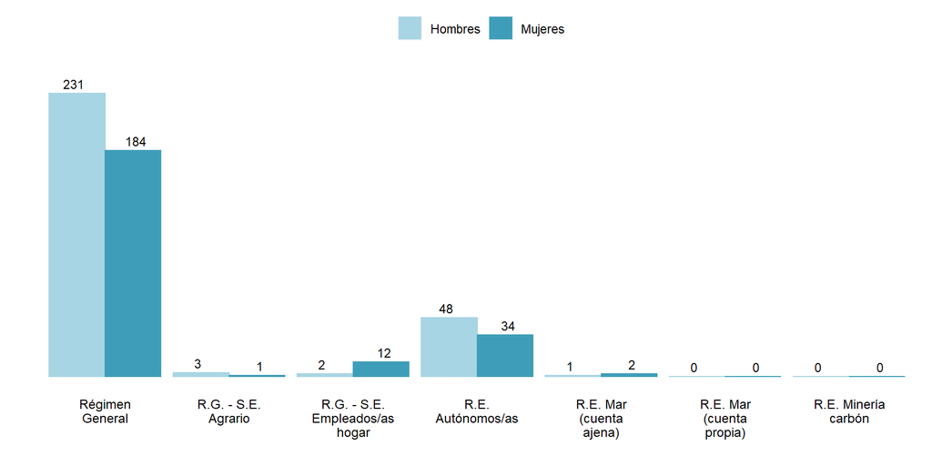

Fuente: [Seguridad Social - MISSM](https://www.seg-social.es/wps/portal/wss/internet/EstadisticasPresupuestosEstudios/Estadisticas/EST8/EST10/EST305/EST307/EST314)

4.2 Parados registrados en el SEPE nacionales de Bosnia y Herzegovina (abril 2023)

Hay en España **68 parados registrados nacionales de Bosnia y Herzegovina**, 34 (50%) hombres y 34 (50%) mujeres.

| TOTAL | Sexo Hombres | Sexo Mujeres | Grupo de edad 16-24 años | Grupo de edad 25-34 años | Grupo de edad 35-44 años | Grupo de edad 45-54 años | Grupo de edad 55 y más años |
| --- | --- | --- | --- | --- | --- | --- | --- |
| 68 | 34 | 34 | 0 | 7 | 16 | 18 | 27 |
| % | 50 | 50 | 0 | 10 | 24 | 26 | 40 |

Parados registrados en el SEPE nacionales de Bosnia y Herzegovina según comunidad autónoma, abril 2023. Cifras absolutas y porcentaje sobre el total de parados extranjeros registrados de nacionalidad bosnioherzegovina

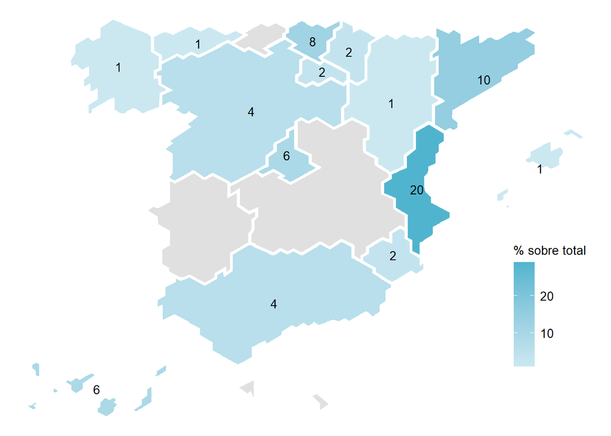

Fuente: [Servicio Público de Empleo Estatal (SEPE)](https://www.sepe.es/HomeSepe/que-es-el-sepe/estadisticas.html)

# 5. Nacionalizados españoles por residencia

Además de la adquisición originaria, el Código Civil considera diferentes modos de **adquisición de la nacionalidad española**:

- **Por adopción**: los extranjeros menores de 18 años adoptados por un español.
- **Por opción**:  
  - Las personas que estén o hayan estado sujetas a la patria potestad de un español.  
  - Las personas cuyo padre o madre hubiera sido originariamente español y nacido en España.  
  - Las personas cuya filiación (identificación de quiénes son sus progenitores) o nacimiento en España se determine después de haber cumplido los 18 años.  
  - Los extranjeros mayores de 18 años adoptados por un español.
- **Por carta de naturaleza**: otorgada discrecionalmente mediante Real Decreto cuando en el interesado concurran circunstancias especiales.
- **Por residencia**, otorgada por el Ministerio de Justicia cuando concurran los siguientes requisitos:  
  1. Haber residido en España un plazo de tiempo que varía según el supuesto.  
  2. La residencia debe ser legal, continuada e inmediatamente anterior a la solicitud.  
  3. El interesado deberá justificar buena conducta cívica y suficiente grado de integración en la sociedad española.
- **Posesión de Estado**: posesión y utilización continuada de la nacionalidad española durante diez años con buena fe y basada en un título inscrito en el Registro Civil.

El 81% del total de adquisiciones de nacionalidad española (no originaria) registradas en el Registro Civil desde 2013 han sido por residencia. En 2022, último periodo publicado por el INE, ese porcentaje fue del 87%.

**Desde 2009 se han nacionalizado españoles por residencia un total de 524 personas con nacionalidad previa bosnioherzegovina.**

En 2022 obtuvieron la nacionalidad por residencia 16 personas.

Evolución de las concesiones de nacionalidad española por residencia a ciudadanos de Bosnia y Herzegovina. 2009─2022

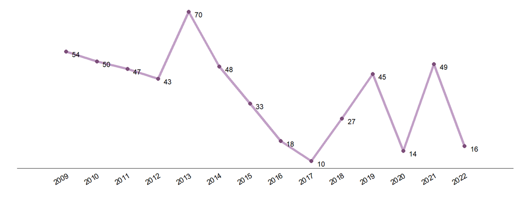

Nota: En 2017 hubo una reducción generalizada de las concesiones de nacionalidad por causas administrativas.

Concesiones de nacionalidad española por residencia a ciudadanos de Bosnia y Herzegovina según plazo exigido / motivo. 2022

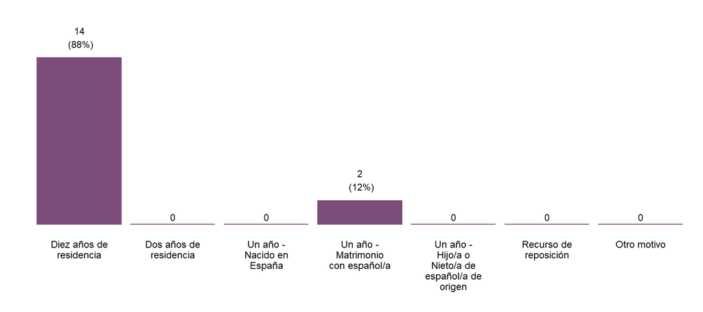

Nota: Existen casos en los que la nacionalidad de origen grabada no coincide con la vía de acceso a la nacionalidad española que debería corresponder según la legislación. Sin embargo, en este momento no se dispone de suficiente información para su correcta depuración.

Concesiones de nacionalidad española por residencia a ciudadanos de Bosnia y Herzegovina según sexo y edad. 2022

| TOTAL | Hombres | % Hombres | Mujeres | % Mujeres |
| --- | --- | --- | --- | --- |
| 16 | 4 | 25 | 12 | 75 |

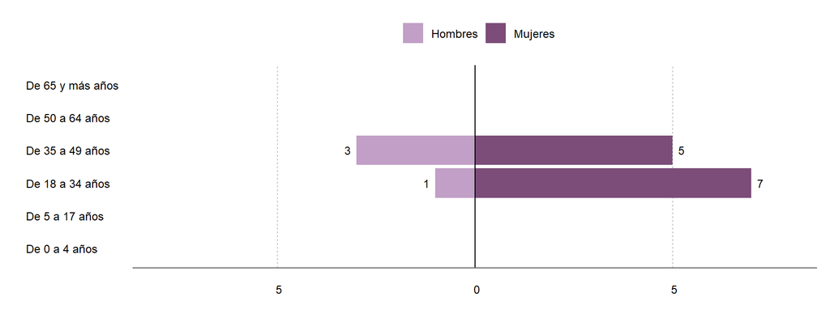

Fuente: [INE](https://www.ine.es/dyngs/INEbase/es/operacion.htm?c=Estadistica_C&cid=1254736177001&menu=resultados&idp=1254735573002), [OPI-SGAM](https://inclusion.seg-social.es/web/opi/estadisticas/catalogo/concesiones_nacionalidad)

# 6. Solicitantes de Protección Internacional

**Durante 2022 ninguna persona nacional de Bosnia y Herzegovina solicitó Protección Internacional** en el territorio de España, ni embajadas españolas, puestos fronterizos ni CIE.

Según avance mensual, **de enero a mayo de 2023 no hubo solicitudes de Protección Internacional de personas con nacionalidad bosnioherzegovina.**

Evolución de los solicitantes de Protección Internacional nacionales de Bosnia y Herzegovina y su distribución según sexo. 2017─2022

(No se han publicado aún datos desagregados por sexo para 2022)

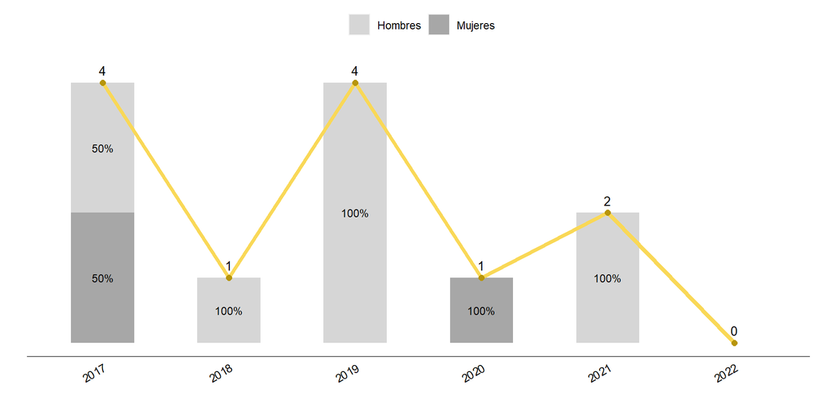

Solicitantes de Protección Internacional nacionales de Bosnia y Herzegovina según lugar de presentación de la solicitud. 2021

(No se han publicado aún datos para 2022)

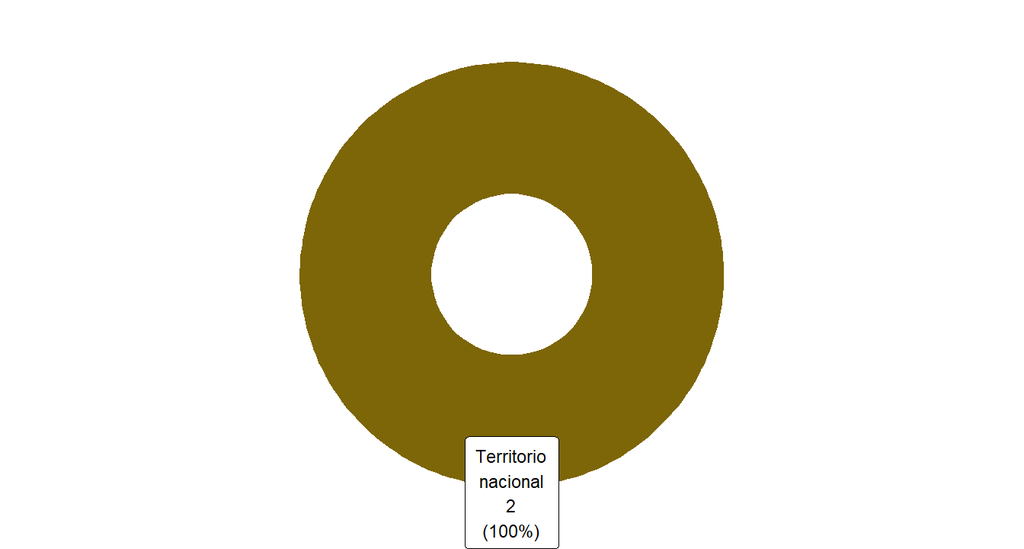

**Durante 2022 se resolvió una única solicitud de Protección Internacional de una persona con nacionalidad bosnioherzegovina.** La resolución fue desfavorable.

Evolución de las resoluciones de solicitudes de Protección Internacional de personas nacionales de Bosnia y Herzegovina. 2017─2022

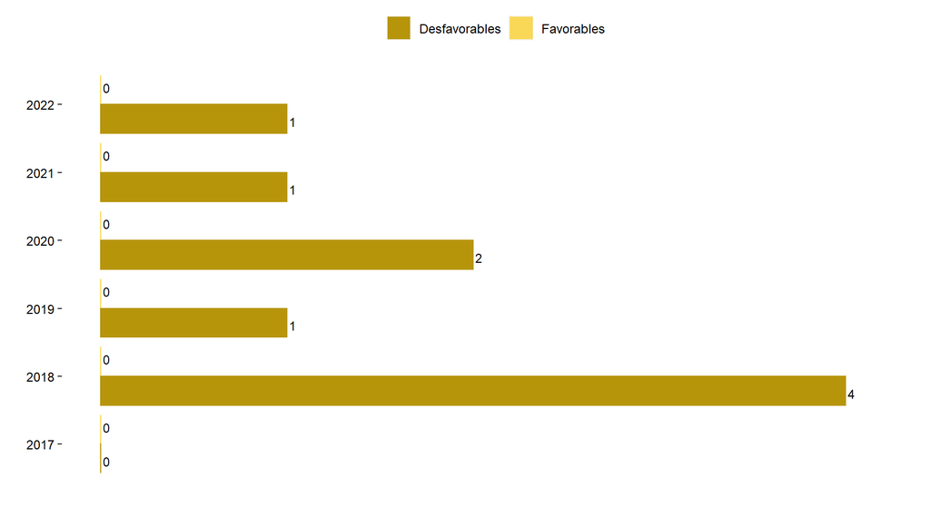

Nota: ‘Favorables’ incluye las resoluciones de reconocimiento de protección internacional (condición de refugiado o derecho a la protección subsidiaria) y las concesiones de autorizaciones de estancia o residencia en España por razones humanitarias.

Tipo de resoluciones de solicitudes de Protección Internacional de personas nacionales de Bosnia y Herzegovina. 2022

| Resolución | Personas | % |
| --- | --- | --- |
| TOTAL | 1 | 100 |
| Reconocimiento condición de refugiado | 0 | 0 |
| Reconocimiento derecho a la protección subsidiaria | 0 | 0 |
| Autor. estancia o residencia por razones humanitarias | 0 | 0 |
| Resolución desfavorable | 1 | 100 |

Fuente: [Oficina de Asilo y Refugio - Ministerio del Interior](https://www.interior.gob.es/opencms/es/servicios-al-ciudadano/tramites-y-gestiones/oficina-de-asilo-y-refugio/datos-e-informacion-estadistica/)

# 7. Beneficiarios del Sistema de Acogida y del programa de Atención Humanitaria

Actualmente no hay ninguna persona nacional de Bosnia y Herzegovina en el Sistema de Acogida para Refugiados, Inmigrantes y Solicitantes de Asilo ni en plazas de Atención Humanitaria.

Fuente: elaborado por SGAM-OPI a partir de información de la aplicación SIRIA (Sistema de Información sobre Programas para Refugiados, Inmigrantes y Solicitantes de Asilo) del [MISSM](https://inclusion.seg-social.es/web/migraciones/acogida-y-atencion-humanitaria)

# 8. Menores extranjeros no acompañados y jóvenes extutelados (de 16 a 23 años)

**A 30/11/2022 había con nacionalidad bosnioherzegovina un chico menor no acompañado o joven extutelado**, de 16 a 23 años, con autorización de residencia en vigor.

Menores no acompañados o jóvenes extutelados, de 16 a 23 años, de Bosnia y Herzegovina con autorización de residencia según tipo de autorización. 30/11/2022

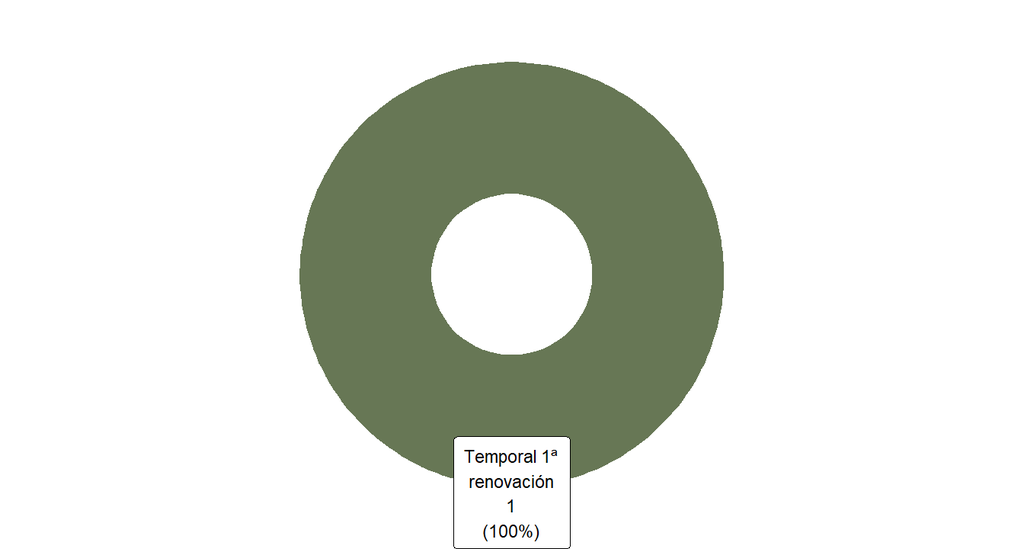

Evolución bimensual de los menores no acompañados o jóvenes extutelados, de 16 a 23 años, de Bosnia y Herzegovina, julio 2021 ─ noviembre 2022

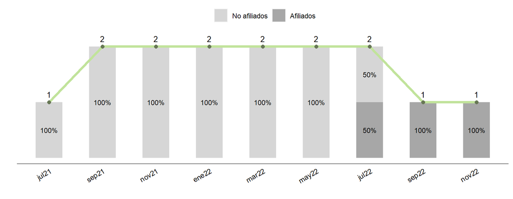

Fuente: [OPI-SGAM](https://inclusion.seg-social.es/web/opi/estadisticas/catalogo/menores)

# 9. Evolución de los flujos regulares (visados y documentación de residencia)

9.1 Flujo de visados

Con respecto al flujo de visados, en 2021 se recuperó la movilidad de antes de la pandemia en general para todas las nacionalidades, aunque el número de visados de corta duración se redujo mucho por un cambio normativo de febrero de 2020 en el Código de Visados para las personas que viajan con frecuencia dentro del espacio Schengen, pudiendo entrar un mayor número de veces por más tiempo, reduciéndose el número de visados expedidos de corta duración de múltiples entradas.

Evolución de visados concedidos a ciudadanos de Bosnia y Herzegovina según clase de visado. 2013─2022

| Clase | 2013 | 2014 | 2015 | 2016 | 2017 | 2018 | 2019 | 2020 | 2021 | 2022 | % 2022 |
| --- | --- | --- | --- | --- | --- | --- | --- | --- | --- | --- | --- |
| TOTAL | 38 | 49 | 43 | 65 | 101 | 123 | 140 | 92 | 122 | 101 | 100 |
| Corta duración | 4 | 1 | 2 | 3 | 1 | 1 | 0 | 0 | 30 | 0 | 0 |
| Larga duración | 34 | 48 | 41 | 62 | 100 | 122 | 140 | 92 | 92 | 101 | 100 |
| Tránsito aeroportuario | 0 | 0 | 0 | 0 | 0 | 0 | 0 | 0 | 0 | 0 | 0 |

Evolución de visados concedidos a ciudadanos de Bosnia y Herzegovina según clase de visado de corta o larga duración. 2010─2022

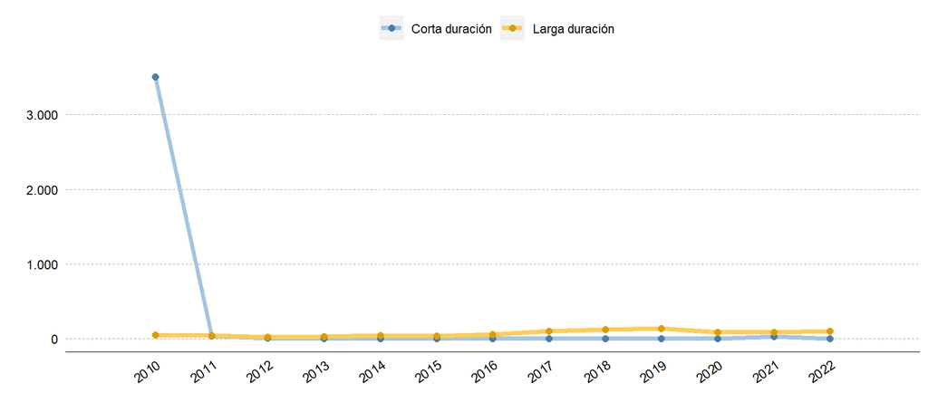

Visados expedidos a nacionales de Bosnia y Herzegovina según clase (corta o larga duración) y tipo/finalidad de visado. 2022

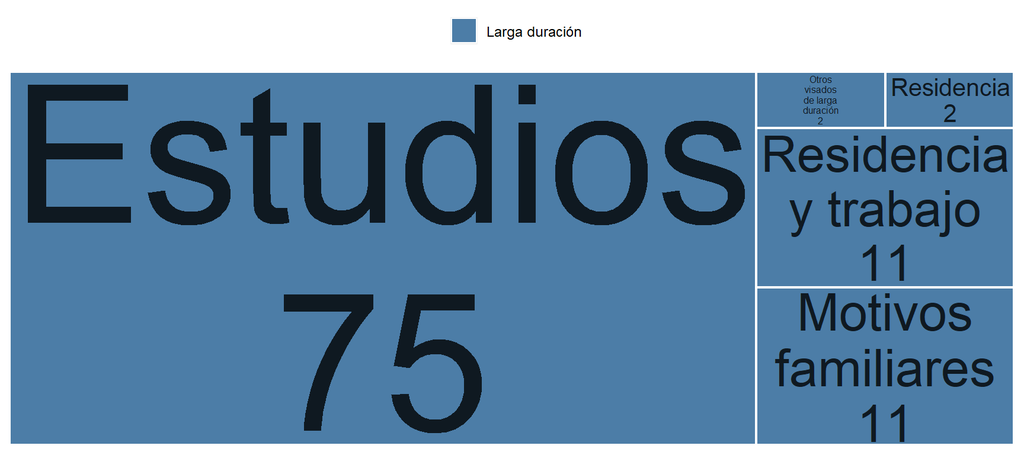

Fuente: [OPI-SGAM](https://inclusion.seg-social.es/web/opi/estadisticas/catalogo/visados)

Los visados de larga duración generalmente dan lugar a documentación de residencia.

9.2 Flujo de documentación de residencia

En los últimos 5 años se ha concedido o expedido documentación de residencia (autorizaciones de residencia o tarjetas de familiar de UE/AELC o de británico) a nacionales de Bosnia y Herzegovina por los siguientes motivos:

Autorizaciones de residencia concedidas a ciudadanos de Bosnia y Herzegovina según motivo. 2017─2021

| Motivo | 2017 | 2018 | 2019 | 2020 | 2021 |
| --- | --- | --- | --- | --- | --- |
| TOTAL | 67 | 88 | 81 | 75 | 100 |
| Residencia larga duración nacional | 17 | 22 | 15 | 10 | 23 |
| Residencia temporal. Trabajo por cuenta ajena | 13 | 17 | 17 | 25 | 23 |
| Residencia temporal. Ley 14/2013 y otras | 13 | 9 | 7 | 19 | 19 |
| Residencia temporal no lucrativa | 1 | 11 | 8 | 7 | 10 |
| Residencia temporal. Reagrupación familiar | 11 | 9 | 10 | 4 | 9 |
| Residencia larga duración Directiva UE | 4 | 8 | 3 | 1 | 6 |
| Residencia duración determinada. Trabajo por cuenta ajena | 1 | 2 | 7 | 1 | 3 |
| Residencia temporal. Circunstancias excepcionales | 4 | 6 | 11 | 4 | 3 |
| Residencia temporal. Excepción a la autorización de trabajo | 1 | 3 | 0 | 2 | 3 |
| Residencia temporal. Trabajo por cuenta propia | 2 | 1 | 3 | 2 | 1 |

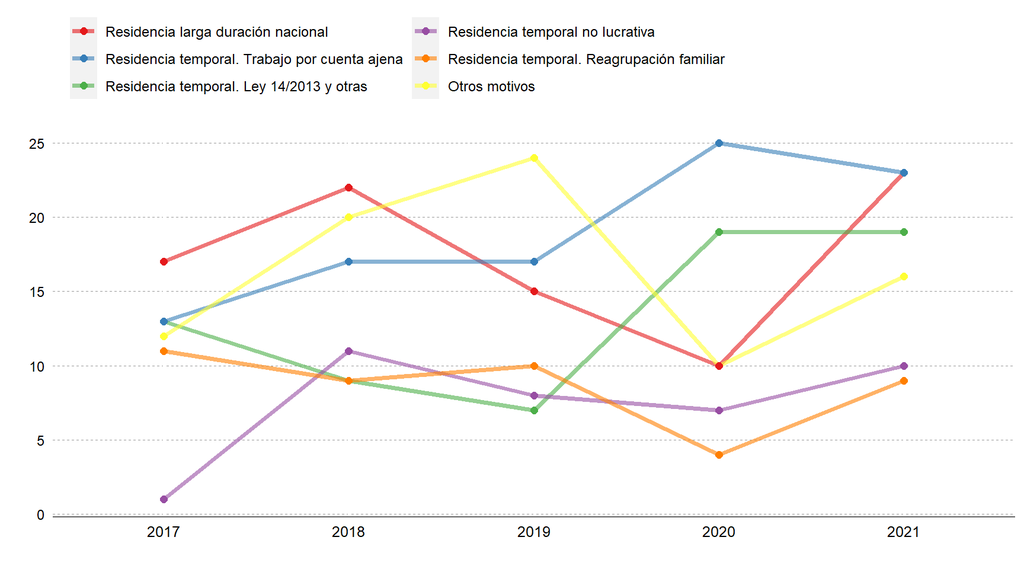

Tarjetas de familiar de ciudadano UE/AELC o TIE de familiar de británico beneficiario del acuerdo de retirada expedidas a nacionales de Bosnia y Herzegovina, según motivo. 2017─2021

| Motivo | 2017 | 2018 | 2019 | 2020 | 2021 |
| --- | --- | --- | --- | --- | --- |
| TOTAL | 27 | 42 | 28 | 27 | 28 |
| Familiar de UE-RU. Temporal | 19 | 28 | 15 | 17 | 17 |
| Familiar de UE-RU. Permanente | 8 | 14 | 13 | 10 | 11 |

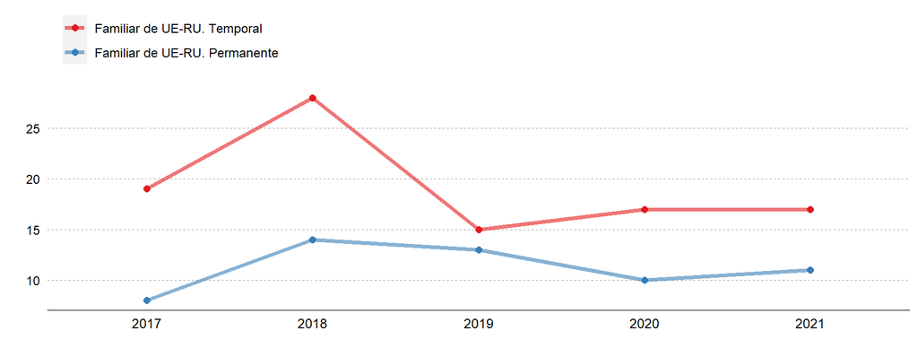

El siguiente gráfico muestra la **distribución de la documentación de residencia (autorizaciones de residencia o tarjetas de familiar de UE/AELC o de británico) concedida o expedida a nacionales de Bosnia y Herzegovina durante 2021, según tipo de trámite**:

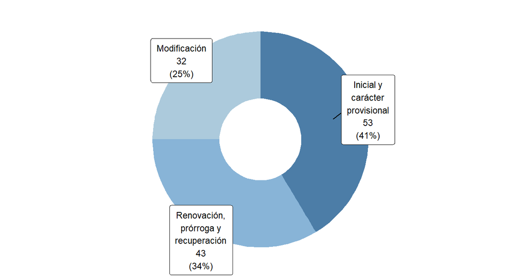

Fuente: [OPI-SGAM](https://inclusion.seg-social.es/web/opi/estadisticas/catalogo/flujo_autorizaciones)

**Comparando con el resto de países de la UE/AELC, el siguiente mapa muestra el número de *primeras* autorizaciones de residencia o de estancia por estudios expedidas a personas de nacionalidad bosnioherzegovina durante 2021**, entendiendo como *primera* aquella autorización concedida a una persona si no le fue concedida ninguna otra en los 6 meses anteriores.

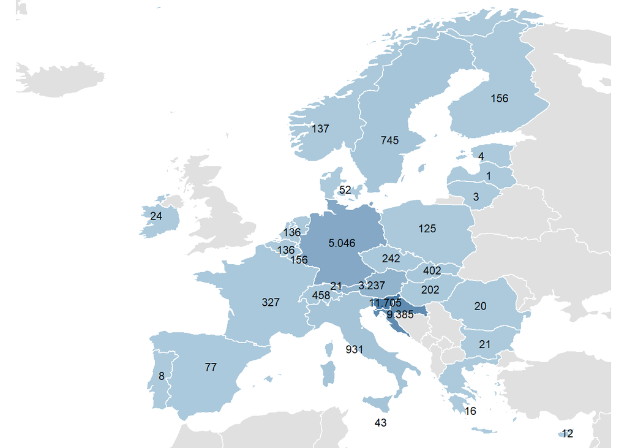

Sin dato disponible: Islandia

Fuente: [Eurostat](https://ec.europa.eu/eurostat/databrowser/view/migr_resfirst/default/table?lang=en)

# 10. Población española residente en Bosnia y Herzegovina

**A 01/01/2023, último dato publicado por el INE, había 95 españoles residentes en Bosnia y Herzegovina** inscritos en el fichero central del Padrón de españoles residentes en el extranjero (PERE); suponen el 0% de todos los españoles residentes en países de Europa.

| TOTAL | Hombres | % Hombres | Mujeres | % Mujeres |
| --- | --- | --- | --- | --- |
| 95 | 53 | 56 | 42 | 44 |

Evolución de los españoles residentes en Bosnia y Herzegovina inscritos en el PERE. 2009─2023

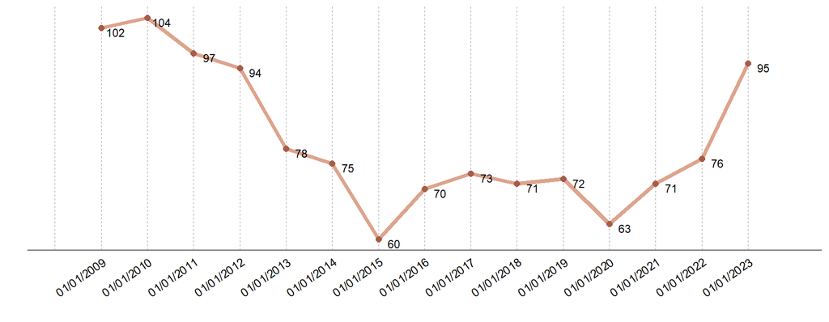

Fuente: [PERE - INE](https://www.ine.es/dyngs/INEbase/operacion.htm?c=Estadistica_C&cid=1254736177014&menu=resultados&secc=1254736195474&idp=1254734710990)